# General linear models: worked solutions

PCB 6455 / BSC 4933: Biometry | Lecture 23

Dr. Brian Maitner

## How to use this

The code from Lecture 23, run, with the numbers it produces, and the habitat exercise solved.

`lm()` gives exact answers, so your numbers should match these. The recipe’s draws are random, so those may differ in the last decimal place.

## Setting up

```r
library(bbmle)
library(biometrydata)

songbirds <- avonet[avonet$Order1 == "Passeriformes", ]
birds <- data.frame(species = songbirds$Species1,
                    family = songbirds$Family1,
                    hwi = songbirds$Hand.Wing.Index,
                    lat = abs(songbirds$Centroid.Latitude),
                    migration_code = songbirds$Migration,
                    habitat_code = songbirds$Habitat.Density)
birds <- na.omit(birds)
nrow(birds)
```

```
[1] 6583
```

## Regression, two ways

```r
m_lat <- mle2(hwi ~ dnorm(mean = a + b * lat, sd = s),
              start = list(a = 15, b = 0, s = 5), data = birds)
lm_lat <- lm(hwi ~ lat, data = birds)

coef(m_lat)
```

```
         a          b          s
15.5883475  0.1712502  7.3183833
```

```r
coef(lm_lat)
```

```
(Intercept)         lat
 15.5873886   0.1712742
```

```r
c(logLik(m_lat), logLik(lm_lat))
```

```
[1] -22448.16 -22448.16
```

## Reading the fit

```r
summary(lm_lat)
```

```
Call:
lm(formula = hwi ~ lat, data = birds)

Residuals:
    Min      1Q  Median      3Q     Max
-19.179  -4.825  -0.610   3.709  41.701

Coefficients:
            Estimate Std. Error t value Pr(>|t|)
(Intercept) 15.58739    0.13874  112.35   <2e-16 ***
lat          0.17127    0.00664   25.79   <2e-16 ***
---
Signif. codes:  0 '***' 0.001 '**' 0.01 '*' 0.05 '.' 0.1 ' ' 1

Residual standard error: 7.325 on 6581 degrees of freedom
Multiple R-squared:  0.09181,   Adjusted R-squared:  0.09167
F-statistic: 665.3 on 1 and 6581 DF,  p-value: < 2.2e-16
```

```r
confint(lm_lat)
```

```
                 2.5 %     97.5 %
(Intercept) 15.3154173 15.8593599
lat          0.1582569  0.1842914
```

```r
sigma(lm_lat)
```

```
[1] 7.324555
```

## The number trap

```r
lm_num <- lm(hwi ~ migration_code, data = birds)
coef(lm_num)
```

```
   (Intercept) migration_code
     11.830011       5.188392
```

```r
birds$migration <- factor(birds$migration_code, levels = 1:3,
                          labels = c("sedentary", "partial", "migratory"))
lm_mig <- lm(hwi ~ migration, data = birds)
coef(lm_mig)
```

```
       (Intercept)   migrationpartial migrationmigratory
         16.940778           6.726748           9.644746
```

```r
coef(lm(hwi ~ migration - 1, data = birds))
```

```
migrationsedentary   migrationpartial migrationmigratory
          16.94078           23.66753           26.58552
```

```r
AIC(lm_num, lm_mig)
```

```
       df      AIC
lm_num  3 44406.50
lm_mig  4 44375.87
```

## Latitude and migration together

```r
lm_add <- lm(hwi ~ lat + migration, data = birds)
lm_int <- lm(hwi ~ lat * migration, data = birds)

AICtab(lm_lat, lm_mig, lm_add, lm_int)
```

```
       dAIC  df
lm_add   0.0 5
lm_int   3.2 7
lm_mig  75.0 4
lm_lat 601.5 3
```

```r
coef(lm_add)
```

```
       (Intercept)                lat   migrationpartial migrationmigratory
       16.07778410         0.06783068         5.97611380         7.80425541
```

```r
confint(lm_add)
```

```
                         2.5 %      97.5 %
(Intercept)        15.81074788 16.34482031
lat                 0.05272058  0.08294079
migrationpartial    5.35521133  6.59701627
migrationmigratory  7.05542700  8.55308382
```

## Are the assumptions met?

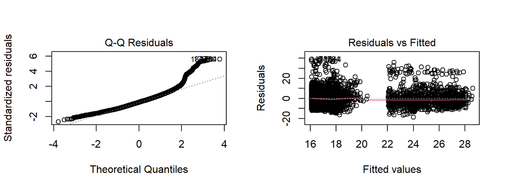

```r
par(mfrow = c(1, 2))
plot(lm_add, which = 2)
plot(lm_add, which = 1)
```

## Who is in the long tail?

```r
# average residual by family: how much more pointed than predicted
head(sort(tapply(resid(lm_add), birds$family, mean), decreasing = TRUE), 5)
```

```
 Hirundinidae     Artamidae   Neosittidae Bombycillidae Campephagidae
     29.60577      17.88997      12.08767      11.07624      10.19338
```

```r
# one fix: model log(hwi), which pulls in the long upper tail
lm_log <- lm(log(hwi) ~ lat + migration, data = birds)
```

Swallows (Hirundinidae) catch insects on the wing, and their wings are far more pointed than the model expects.

## On the log scale

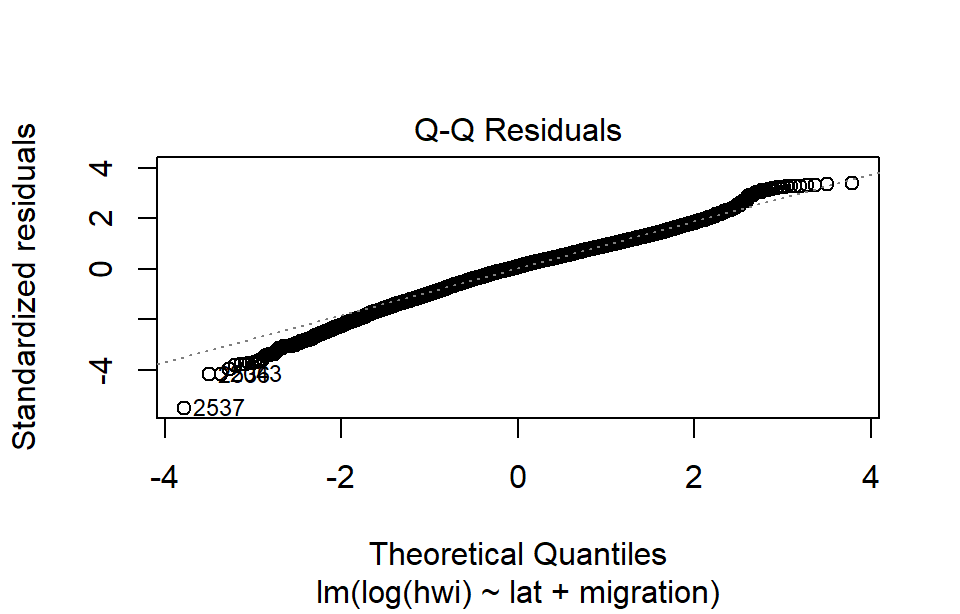

```r
plot(lm_log, which = 2)
```

Much closer to the line, with the long upper tail gone. Thursday’s generalized linear models are the other route.

## Intervals, the quick way

```r
new_bird <- data.frame(lat = 45,
                       migration = factor("migratory", levels = levels(birds$migration)))

predict(lm_add, newdata = new_bird, interval = "confidence")
```

```
       fit      lwr      upr
1 26.93442 26.33081 27.53803
```

```r
predict(lm_add, newdata = new_bird, interval = "prediction")
```

```
       fit      lwr      upr
1 26.93442 13.20592 40.66292
```

## The same intervals, by Lecture 21’s recipe

```r
set.seed(23)
draws <- MASS::mvrnorm(1000, mu = coef(lm_add), Sigma = vcov(lm_add))

# the mean for a migratory bird at 45 degrees, for each draw
mu_draws <- draws[, "(Intercept)"] + draws[, "lat"] * 45 + draws[, "migrationmigratory"]
quantile(mu_draws, c(0.025, 0.975))
```

```
    2.5%    97.5%
26.33571 27.53193
```

```r
# add the scatter of one new species
quantile(rnorm(1000, mean = mu_draws, sd = sigma(lm_add)), c(0.025, 0.975))
```

```
    2.5%    97.5%
12.99073 40.90065
```

## Drawing the predictions

```r
library(ggplot2)

grid <- expand.grid(lat = 0:70, migration = levels(birds$migration))
conf <- predict(lm_add, newdata = grid, interval = "confidence")
pred <- predict(lm_add, newdata = grid, interval = "prediction")
grid <- data.frame(grid, conf, pred_lwr = pred[, "lwr"], pred_upr = pred[, "upr"])
head(grid, 3)
```

```
  lat migration      fit      lwr      upr pred_lwr pred_upr
1   0 sedentary 16.07778 15.81075 16.34482 2.359961 29.79561
2   1 sedentary 16.14561 15.88924 16.40199 2.427995 29.86323
3   2 sedentary 16.21345 15.96727 16.45962 2.496013 29.93088
```

## The figure

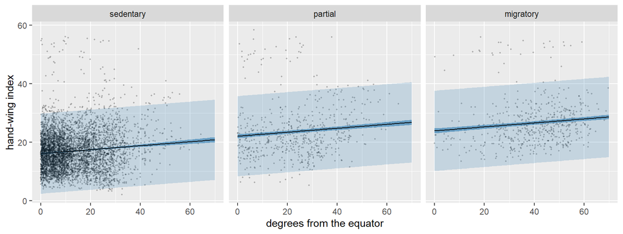

```r
ggplot(grid, aes(x = lat)) +
  geom_point(data = birds, aes(y = hwi), size = 0.3, alpha = 0.2) +
  geom_ribbon(aes(ymin = pred_lwr, ymax = pred_upr), fill = "#2a7ab0", alpha = 0.2) +
  geom_ribbon(aes(ymin = lwr, ymax = upr), fill = "#2a7ab0", alpha = 0.6) +
  geom_line(aes(y = fit)) +
  facet_wrap(~ migration) +
  labs(x = "degrees from the equator", y = "hand-wing index")
```

## Does the model match the data?

```r
# each species' own prediction interval
pi_data <- predict(lm_add, newdata = birds, interval = "prediction")
inside <- birds$hwi > pi_data[, "lwr"] & birds$hwi < pi_data[, "upr"]

mean(inside)                                           # share inside: about 0.95?
```

```
[1] 0.9646058
```

```r
mean(birds$hwi[!inside] > pi_data[!inside, "upr"])     # share of misses above
```

```
[1] 0.9098712
```

Close to 95% inside, but nearly all the misses are above the band: the band is symmetric and the data have a long upper tail, as the Q-Q plot showed.

## Good enough?

```r
exp(confint(lm_log))   # each effect is now "times"
```

```
                       2.5 %    97.5 %
(Intercept)        14.886598 15.330767
lat                 1.002276  1.003945
migrationpartial    1.307940  1.400479
migrationmigratory  1.433468  1.556659
```

```r
exp(predict(lm_log, newdata = new_bird, interval = "prediction"))
```

```
       fit      lwr      upr
1 25.95116 12.18823 55.25516
```

```r
predict(lm_add, newdata = new_bird, interval = "prediction")
```

```
       fit      lwr      upr
1 26.93442 13.20592 40.66292
```

Migrants still have more pointed wings, and latitude still points the same way. What changes is the prediction for one new species: the log model’s interval reaches much higher, where the swallows are.

## Your turn: habitat

```r
lm_hab_num <- lm(hwi ~ lat + migration + habitat_code, data = birds)

birds$habitat <- factor(birds$habitat_code, levels = 1:3,
                        labels = c("dense", "semi-open", "open"))
lm_hab_fac <- lm(hwi ~ lat + migration + habitat, data = birds)

AICtab(lm_add, lm_hab_num, lm_hab_fac)
```

```
           dAIC  df
lm_hab_fac   0.0 7
lm_hab_num  80.4 6
lm_add     294.2 5
```

```r
confint(lm_hab_fac)
```

```
                        2.5 %     97.5 %
(Intercept)        15.3478765 15.9239546
lat                 0.0341886  0.0643091
migrationpartial    4.3173973  5.5539705
migrationmigratory  6.8531720  8.3187455
habitatsemi-open    0.1544414  0.8943103
habitatopen         3.9932339  5.0232712
```

## Your turn, in biology

Habitat matters on top of migration and latitude, and it has to go in as a factor: forest and semi-open songbirds differ by only 0.5 HWI points, while open-country songbirds have wings about 4.5 points more pointed than forest birds. The numeric version forces those two steps to be equal.

## For anyone fast

```r
# does the habitat effect depend on migration?
lm_hab_int <- lm(hwi ~ lat + migration * habitat, data = birds)

# is the latitude effect curved?
lm_quad <- lm(hwi ~ lat + I(lat^2) + migration, data = birds)

AICtab(lm_hab_fac, lm_hab_int)
```

```
           dAIC df
lm_hab_int  0   11
lm_hab_fac 43   7
```

```r
AICtab(lm_add, lm_quad)
```

```
        dAIC df
lm_quad  0.0 6
lm_add  21.7 5
```

```r
coef(lm_quad)
```

```
       (Intercept)                lat           I(lat^2)   migrationpartial
      16.623311852       -0.016951703        0.001966987        5.926197295
migrationmigratory
       7.118722789
```

Both help. The squared term is positive: wings change little across the tropics and become more pointed beyond them.